10.14.5 Using a plot of x versus y when a plot of (x+y) versus (x-

y) is more informative

If you have two ways of measuring the same quantity and you want to see if

they agree, use a Bland-Altman plot. So instead of plotting x versus y, plot

x+y versus x-y. Then differences between the two variables will be on the y

axis - so you hope all the values will be near zero. It also makes it easier to

see if there are magnitude effects, for example when small values of x and y

are more similar than large values of x and y.

10.14.6 Failing to ensure that multiple panels have the same

vertical scale

When you have multiple panels make sure all axes are on the same scale

otherwise differences will not be correctly perceived.

[figure not shown]

10.14.7 Failing to consider the point of the graph but rather just

using some standard form

In some disciplines certain plots are used by custom. However, each plot in

a paper should communicate a message. If they do not, even if they are

“customary” they should be eliminated.

10.14.8 Bar plots with antennas

These plots are sometimes called dynamite plots and are very low

information density. Instead, scatterplots should be used.

10.14.9 Being inconsistent about color choice across multiple

panels or figures

If you use color to label points in a figure according to a variable, then

every figure or panel in your paper should use those same colors to label

points by the same variable.

10.14.10 Aligning things horizontally when comparisons would

be better made vertically, or vice versa

When using multiple panels, the panels should be lined up according to the

axis for comparison. So if the points are to be compared on the x-axis

values they should be aligned vertically and if they are to be compared on

the y-axis values they should be aligned horizontally.

10.14.11 Any of the other issues in Karl Broman’s presentation

on displaying data badly

There are many other common visualization mistakes. A large number of

these are summarized in Karl Browman’s excellent presentation on

displaying data badly.

[figure not shown]

11. Presenting data

Giving data science talks can help you:

Meet people

Get people excited about your ideas/software/results

Help people understand your ideas/software/results

The importance of the first point can’t be overstated. The primary reason

you are giving talks is for people to get to know you. Being well known and

well regarded can make a huge range of parts of your job easier. So first and

foremost make sure you don’t forget to talk to people before, after, and

during your talk.

Point 2 is more important than point 3. As a data scientist, it is hard to

accept that the primary purpose of a talk is advertising, not data science.

See for example Hilary Mason’s great presentation Entertain, don’t teach.

That being said, be very careful to avoid giving a TED talk. If you are

giving a data science presentation the goal is to communicate specific ideas.

So while you are entertaining, don’t forget why you are entertaining.

11.1 Tailor your talk to your audience

It depends on the event and the goals of the event. Here is a non-

comprehensive list:

Small group meeting:

Goal: Update people you work with on what you are doing and

get help.

What to talk about: Short intro on your problem, brief update on

what you’ve tried, long discussion about where you are

going/what you need help on.

Short talk at conference:

Goal: Entertain people, get people to read your paper/blog or use

your software.

What to talk about: Short intro on your problem, brief

explanation of solution, links to software

Long format formal talk:

Goal: Entertain people, get people to read your software, make

them understand your problem/solution

What to talk about: Intro to your problem, how you solved it,

results, and connection to broader ideas

Job talk:

Goal: Get a job, entertain people, make them understand your

problem/solution

What to talk about: Brief overview of who you are, intro to your

(single) problem, how you solved it, results, summary of what

you have done/plan to do.

11.2 Order your talk in story format

The biggest trap in giving a talk is assuming that other people will follow

you because you follow the talk. It is key to be aware of what your audience

knows and doesn’t know. In general it is always better to assume your

audience knows less than you think they do. People like to feel smart. I

have rarely heard complaints about people who went too basic in their

explanations, but frequently hear complaints about people being lost. That

being said, here are some structural tips. Your mileage may vary.

Always lead with a brief, understandable to everyone statement of

the scientific problem that lead to your data.

Explain the data and measurement technology before you explain the

features you will use

Explain the features you will use to model data before you explain the

model

When presenting results, make sure you are telling a story.

The last point is particularly important. Usually by the results section

people are getting a little antsy. So a completely disparate set of results with

little story behind them is going to drive people bonkers. Make sure you

explain up front where the results are going (e.g. “Our results will show our

method is the fastest/most accurate/best ever.”), then make sure that your

results are divided into sections by what point they are making and

organized just like they would be if you were telling a story.

11.3 Use large fonts

Fonts can never be too big. Go huge. Small fonts will be met with anger

11.4 Include contact information early

Your title slide should have a contactable form of you (twitter handle, email

address, etc.)

11.5 All figures should have large axis labels in plain

English.

Figure axes should be readable from the back of the room.

11.6 Be sure to attribute all images and text you borrow

Any figure you borrow off the internet should have a web link to the source.

Any figure you borrow off a paper should have a web link to the paper. Any

time you use someone else’s slide you should put “Slide courtesy of So and

so” with a link to their page.

11.7 In general use a solid background and opposite

color font

Unless you have experience in design, using pictures for backgrounds or

similar color backgrounds and fonts are dangerous for presentations.

11.8 Minimize text on slides

Whenever possible break multiple bullet points up into individual slides

with only one bullet point on them. If you can, go textless with only images.

That way you won’t fall into the trap of reading your slides.

11.9 Explain every figure in your talk in detail

If you have a figure in your talk you should present it in the following way.

Explain what the figure is supposed to communicate (e.g. “this figure

shows our method has higher accuracy”)

Explain the figure axes (e.g. “the y-axis is sensitivity the x-axis is 1-

specificity”)

Explain what trends the audience should look for (e.g. “curves that go

straight up at zero and across the top of the plot are best”)

If you don’t have time to fully explain a figure, than simplify it, or omit it.

11.10 Use equations to make ideas concrete, but use

them sparingly

If you are giving a data talk you will often have some equations. That is ok.

But the way you present them is critically important to giving an

understandable talk. Here are a few important points:

Before presenting an equation explain the data

Whenever possible use words instead of symbols in equations

(Expression = Noise + Signal is better than E = N + S is better than Y

= X + E)

Use no more than two subscripts whenever possible

When explaining an equation

First explain the point of the equation (“we are trying to model

expression as a function of noise and signal”)

Then explain what each symbol is (“E is expression, N is noise,

etc.”)

Then explain how the model relates them (“E is a linear function

of signal and noise”)

11.11 Be willing to say “I don’t know”

Inevitably you will get hard questions during your talk. The most important

point is not to panic and not to get defensive. It is way better to just say I

don’t know, then to get upset.

When you get asked a really hard question you should:

[figure not shown]

Take a second and a deep breath. If necessary, ask the person to repeat

the question.

Answer the question the best you can come up with on the spot

Say I don’t know if you don’t know. If you say I don’t know, then you

can give your best guess and explain it is a guess.

11.12 Distiguish your response type when answering

questions

The key is to distinguish what kind of response you are giving. Are you

giving a response where you know the answer because you actually looked

into that? Are you giving a complete guess where you have no idea? Or,

what is more likely, are you somewhere in between?

11.13 Never be aggressive

Almost everywhere you give a talk there will be a person who is

upset/intense/aggressive. Do not fall into the temptation to be aggressive

in return. Answer their first questions politely just like everyone else. If

they keep asking really aggressive/lots of questions, you are within your

rightst to say: “You are bringing up a lot of good issues, I’d be happy to

discuss with you after the presentation more in depth, but in the interest of

time I’m going to move on to the next part of my talk”. It is ok to keep

things moving and to finish on time.

11.14 Finish on time

Do it. People will love you for it. If you are the last speaker in a session and

others have gone long, adapt and go shorter. The value you gain by making

your audience happy >>>> the extra 5 minutes of details you could have

explained.

11.15 Where you should put your talk

If you have weblinks in your talk you need to post it online. There is no

way people will write down any of the links in your talk. Two good places

to put your talks are

https://speakerdeck.com/

[figure not shown]

http://www.slideshare.net/.

Slideshare is easier to view on mobile phones and iPads, which is the most

likely place someone will read your talk.

This chapter builds on and expands the book author’s talk guide.

[figure not shown]

12. Reproducibility

Reproducibility involves being able to recalculate the exact numbers in a

data analysis using the code and raw data provided by the analyst.

Reproducibility is often difficult to achieve and has slowed down the

discovery of important data analytic errors. Reproducibility should not be

confused with “correctness” of a data analysis. A data analysis can be fully

reproducible and recreate all numbers in an analysis and still be misleading

or incorrect.

12.1 Have a data analysis script

The primary way to ensure an analysis is reproducible is to create code

scripts that exactly generate all numbers and figures in an analysis. R

markdown and iPython notebooks are both useful for organizing scripts.

These tools integrate code, plain text, and figures into one document and

are examples of what is called, “literate programming”. An R markdown

document includes text, code, and figures and can easily be converted into

pdf or HTML format (Figure 12.1, adapted from R markdown

documentation).

[figure not shown]

Figure 12.1 An example of an R markdown document

12.2 Record versions of software and parameters

If you are using open-source software such as R or Python, then packages

will often be updated and their exact behavior may change. At minimum

you should record what versions of the software you used to perform an

analysis. In R you can get this information with the sessionInfo()

command or the devtools::session_info() command, which is more

informative.

12.3 Organize your data analysis

A good organizational structure for data analysis files is to keep separate

folders for:

[figure not shown]

Data

raw data

processed data

Figures

Exploratory figures

Final figures

R code

Raw or unused scripts

Data processing scripts

Analysis scripts

Text

README files explaining what all the components are

Final data analysis products like presentations/writeups

12.4 Use version control

When performing analysis it is a good idea to keep track of the version of

the software you are writing. One very popular approach is to use Github.

You can put your R scripts, R markdown documents, and small data sets on

Github, then use the version control system Git to manage your analysis.

Github is an example of a distributed version control system where a

version of the files is on your local computer and also available at a central

server (Figure 12.2, adapted from git documentation). Multiple people can

then work on the analysis code and push changes to the central server.

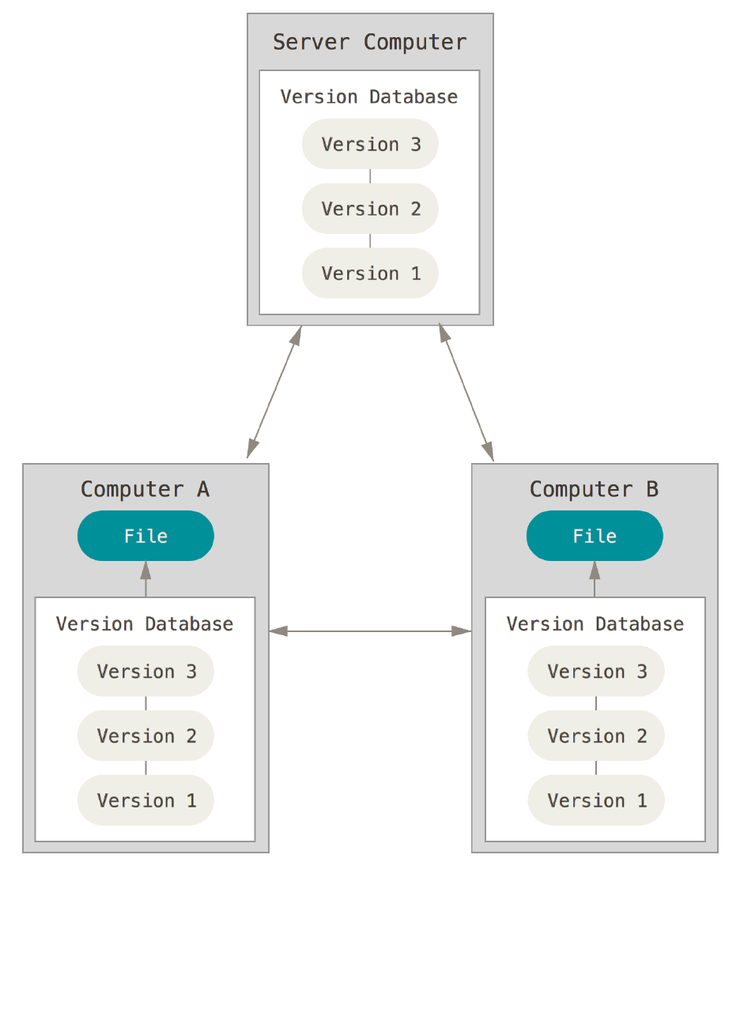

Figure 12.2 Distributed version control

Using version control will help you keep track of changes to your analysis

and their impact on the results.

12.5 Set a seed

When your calculations involve random sampling - for example if you use

the bootstrap or permutations - then you need to set a random number seed.

This will ensure that the pseudorandom numbers generated by the computer

will always be the same when different people run your analysis. In R you

can do this with the command set.seed(13323) where 13323 can be

replaced with any positive integer.

12.6 For large data sets, save intermediate results and

especially how you got them

If you are working with large data sets, create a script to calculate summary

measures. Include all the same details about version numbers and

parameters. Then save the intermediate data set in a tidy format in a csv or

tab-delimited file for easy sharing.

12.7 Have someone else run your analysis

The best way to check reproducibility is to have someone else, ideally on a

different type of computer, run your data analysis scripts. They should be

able to run the analysis and get the same figures and results without having

to ask you questions.

This chapter builds on and expands the book author’s data sharing guide.

12.8 Common mistakes

12.8.1 Not using a script for your analysis

If you describe your analysis in written documentation, it is much easier to

make mistakes of reproducibility.

12.8.2 Not recording version numbers or parameters used

It is important to record: (1) the type of computer used, (2) the version of all

software used, and (3) all parameters you used when performing an

analysis.

12.8.3 Not sharing data or code

For every analysis you perform you should include a link to the code and

data you used to perform the analysis.

12.8.4 Using reproducibility as a weapon

If you reproduce someone else’s analysis and identify a problem, bug or

mistake you should contact them and try to help them resolve the problem

rather that pointing the problem out publicly or humiliating them.

13. A few matters of form

Report estimates followed by parentheses.

When reporting P-values do not report numbers below machine

precision. P-values less than 2 x 10e-16 are generally below machine

precision and inaccurate.

Reporting a P-value of 1.35 x 10e-25 is effectively reporting a P-value

of 0 and caution should be urged. A common approach is to report

censored P-values such as P < 1 x 10e-8.

When reporting permutation P-values avoid reporting a value of zero.

P-values should be calculated as (K + 1)/(B + 1) where B is the

Do not report estimates with over-precision.

If measurements are only accurate to the tenths digit, do not report an

estimate of 6.8932

When programing variable names should be lower case, with words

separated by underscores, and as explicit as possible in data frames

you are analyzing.

The date of visiting a website might be named date_of_visit.

In written analysis variable names should always be reported in plain

language, not as variable names.

The date of visiting a website would be described as “the date of visit

variable”.

14. The data analysis checklist

This checklist provides a condensed look at the information in this book. It

can be used as a guide during the process of a data analysis, as a rubric for

grading data analysis projects, or as a way to evaluate the quality of a

reported data analysis.

14.1 Answering the question

1. Did you specify the type of data analytic question (e.g. exploration,

association causality) before touching the data?

2. Did you define the metric for success before beginning?

3. Did you understand the context for the question and the scientific or

business application?

4. Did you record the experimental design?

5. Did you consider whether the question could be answered with the

available data?

14.2 Checking the data

1. Did you plot univariate and multivariate summaries of the data?

2. Did you check for outliers?

3. Did you identify the missing data code?

14.3 Tidying the data

1. Is each variable one column?

2. Is each observation one row?

3. Do different data types appear in each table?

4. Did you record the recipe for moving from raw to tidy data?

5. Did you create a code book?

6. Did you record all parameters, units, and functions applied to the data?

14.4 Exploratory analysis

1. Did you identify missing values?

2. Did you make univariate plots (histograms, density plots, boxplots)?

3. Did you consider correlations between variables (scatterplots)?

4. Did you check the units of all data points to make sure they are in the

right range?

5. Did you try to identify any errors or miscoding of variables?

6. Did you consider plotting on a log scale?

7. Would a scatterplot be more informative?

14.5 Inference

1. Did you identify what large population you are trying to describe?

2. Did you clearly identify the quantities of interest in your model?

3. Did you consider potential confounders?

4. Did you identify and model potential sources of correlation such as

measurements over time or space?

5. Did you calculate a measure of uncertainty for each estimate on the

scientific scale?

14.6 Prediction

1. Did you identify in advance your error measure?

2. Did you immediately split your data into training and validation?

3. Did you use cross validation, resampling, or bootstrapping only on the

training data?

4. Did you create features using only the training data?

5. Did you estimate parameters only on the training data?

6. Did you fix all features, parameters, and models before applying to the

validation data?

7. Did you apply only one final model to the validation data and report

the error rate?

14.7 Causality

1. Did you identify whether your study was randomized?

2. Did you identify potential reasons that causality may not be

appropriate such as confounders, missing data, non-ignorable dropout,

or unblinded experiments?

3. If not, did you avoid using language that would imply cause and

effect?

14.8 Written analyses

1. Did you describe the question of interest?

2. Did you describe the data set, experimental design, and question you

are answering?

3. Did you specify the type of data analytic question you are answering?

4. Did you specify in clear notation the exact model you are fitting?

5. Did you explain on the scale of interest what each estimate and

measure of uncertainty means?

6. Did you report a measure of uncertainty for each estimate on the

scientific scale?

14.9 Figures

1. Does each figure communicate an important piece of information or

address a question of interest?

2. Do all your figures include plain language axis labels?

3. Is the font size large enough to read?

4. Does every figure have a detailed caption that explains all axes,

legends, and trends in the figure?

14.10 Presentations

1. Did you lead with a brief, understandable to everyone statement of

your problem?

2. Did you explain the data, measurement technology, and experimental

design before you explained your model?

3. Did you explain the features you will use to model data before you

explain the model?

4. Did you make sure all legends and axes were legible from the back of

the room?

14.11 Reproducibility

1. Did you avoid doing calculations manually?

2. Did you create a script that reproduces all your analyses?

3. Did you save the raw and processed versions of your data?

4. Did you record all versions of the software you used to process the

data?

5. Did you try to have someone else run your analysis code to confirm

they got the same answers?

14.12 R packages

1. Did you make your package name “Googleable”

2. Did you write unit tests for your functions?

3. Did you write help files for all functions?

4. Did you write a vignette?

5. Did you try to reduce dependencies to actively maintained packages?

6. Have you eliminated all errors and warnings from R CMD CHECK?

[figure not shown]

15. Additional resources

15.1 Class lecture notes

Johns Hopkins Data Science Specialization and Additional resources

Data wrangling, exploration, and analysis with R

Tools for Reproducible Research

Data carpentry

15.2 Tutorials

Git/github tutorial

Make tutorial

knitr in a knutshell

Writing an R package from scratch

15.3 Leek group guides

To data sharing

To giving talks

To developing R packages

15.4 Books

An introduction to statistical learning

Advanced data analysis from an elementary point of view

Advanced R programming

OpenIntro Statistics

Statistical inference for data science